# Meaningful engagement on *MyNZTE*

Author

Sam Verevis

## *MyNZTE* Customer Engagement

Understanding customer interactions through online platforms offers several key advantages in understanding how services provided are indeed, having the desired engagement you want. That is, website data can reveal how long customers spend on the site per session, how many of them ‘bounce’ after logging in, most frequently used functions or actions they take, and summarised search queries can reveal what might be ‘top of mind’ for your customers.

All of this readily available data can help guide website investment decisions, reveal how customers consume content, figure out current topics of interest, and identify where engagement might not be working as well.

Over the six months from March through to August of 2021, *MyNZTE* had about 11,000 unique customer sessions, which came from about 3,700 different organisations of which a third were the NZTE focus group. While the length of each session varied widely across the customer base (from 0 minutes to an entire day), the mid-point of each session across users was about 1 minute (see Figure 1). In combination, the bounce rate for the website across this period was about 23% - suggesting almost *80%* of *MyNZTE* users are engaging beyond a single page view, relative to 23% of the sessions, in which users left immediately after logging on.

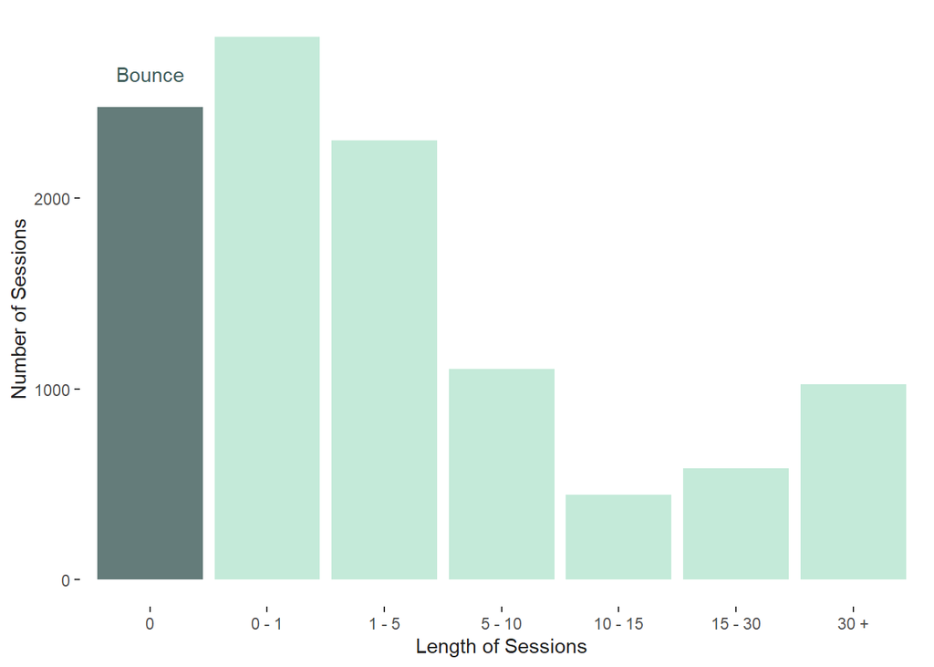

Figure 1: Number of user sessions over the 6 month period

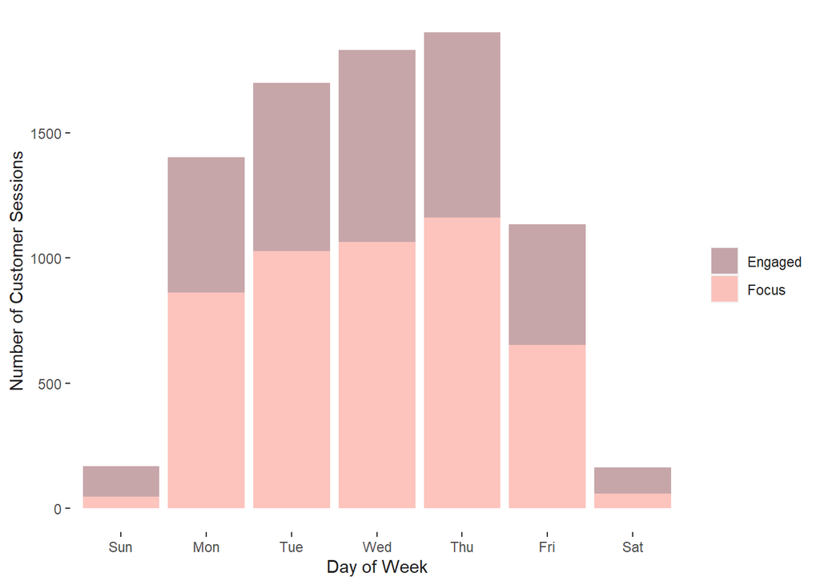

(a) Customer sessions across the week day

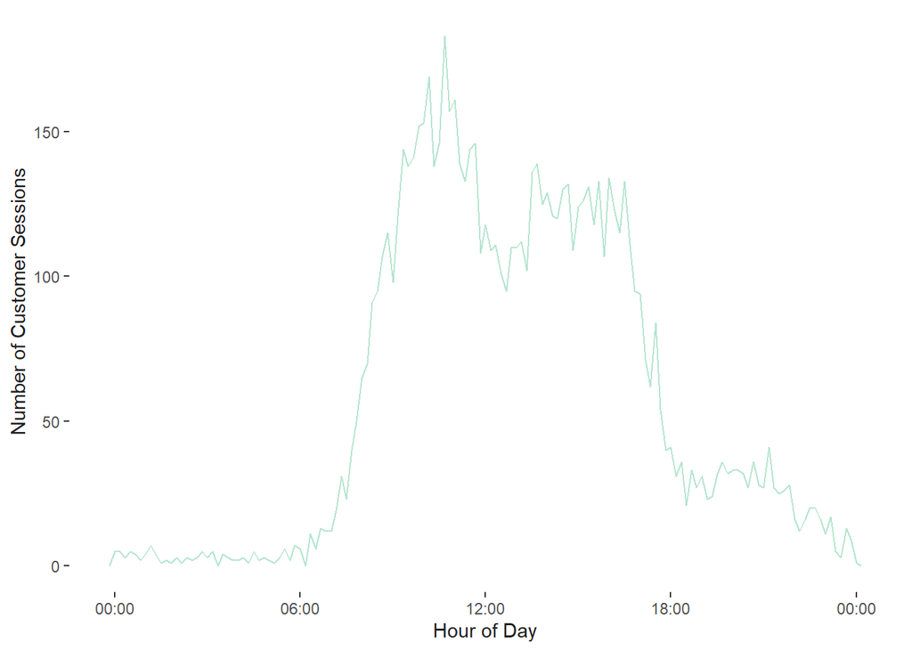

(b) Customer sessions during time of day

Figure 2: Timeline of customer sessions over the 6 month period

## Varying levels of meanginful engagement

While the number of industry based users are predominantly in manufacturing (35%), followed by food and beverage (28%), then tech (24%) and services (13%), the largest user activity comes from the food and beverage sector making up 42% of activity, then manufacturing (making up 33%). However, the tech and services industries users tend to be under-represented in activity relative to the total number of organisations on the platform (as shown in Figure 3).

However, despite the lower user engagement from the services and tech businesses, the average time spent on the platform across sectors, doesn’t vary drastically, with tech and services spending the least amount of time on average (11 minutes) and food and beverages spending the most (about 15 minutes on average). Suggesting that, while *MyNZTE* might have the highest engagement from the food, beverage and manufacturing businesses, the platform is catering to the tech and service businesses needs.

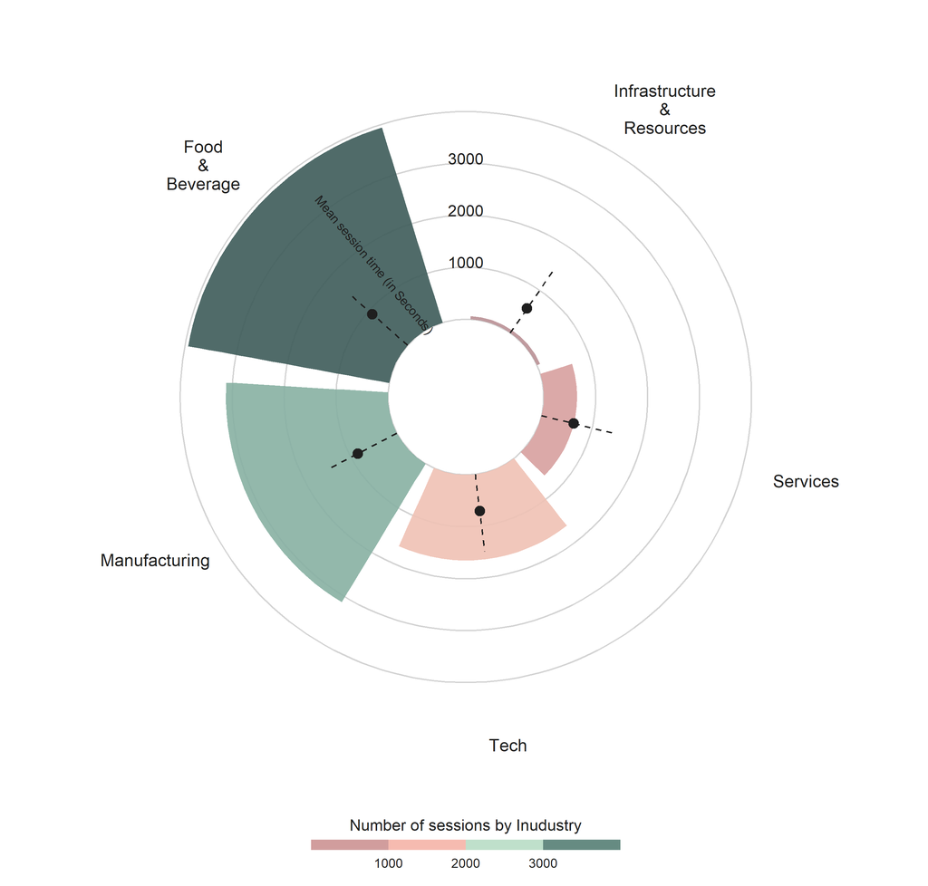

Figure 3: industry

Figure 4 shows the total number of times an organisation has engaged with the platform as well as total time spent by the two NZTE customer segments (Focus vs. Engaged) over the 6 month period. The focus group tends to repeatedly use the platform more, with an average log-in rate of 5.3 times per business over the 6 month period, compared to engaged businesses, who on average had a log-in rate of 2.5. This also corresponds to a higher session length time for the focus group, who tend to use *myNZTE* 14 minutes per session on average, compared to the engaged group, in which the central tendency was 9 minutes per session.

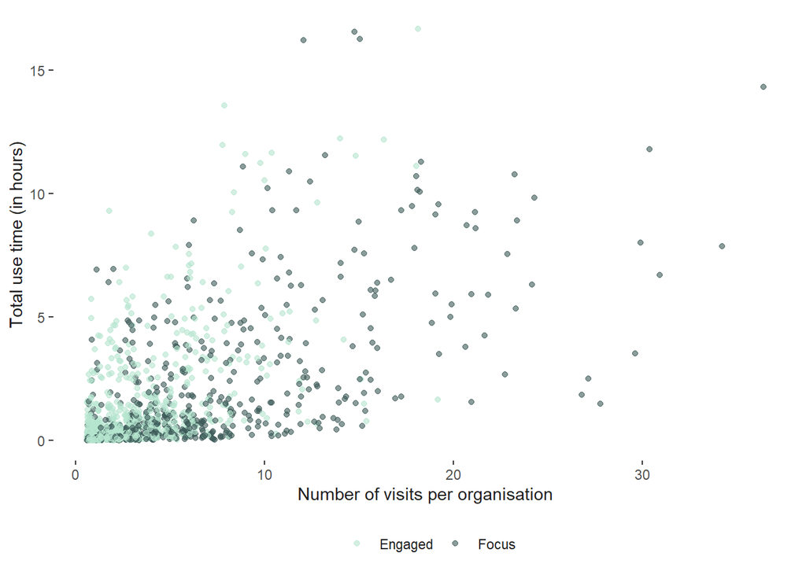

Figure 4: Organisation uses vs time spent

## Understanding the *MyNZTE* value-add

How customers spend their time on the platform reveals where they find the most value-add on the website. From a business perspective this is important feature that will help guid future platform upgrades, content prioritisation, and maintenance efforts.

The **Discover** function has the largest number of hits, just shy of 20,000 (making up 33% of total hits), which is true for both the engaged and focus groups (see Figure 5). This is followed by **Session** (of 11,000 hits), **Home** (of 7,100 hits), and then **Attend** (of 6,900 hits). Aside from logging in, customers across both groups tend to view articles the most (15% of total user activity), scroll the home landing (15%), scroll the discover landing (11%), and the attend landing page (7%). Suggesting that this is where they glean the most useful content from the *MyNZTW* platform and shows where they’re likely to spend most of their time.

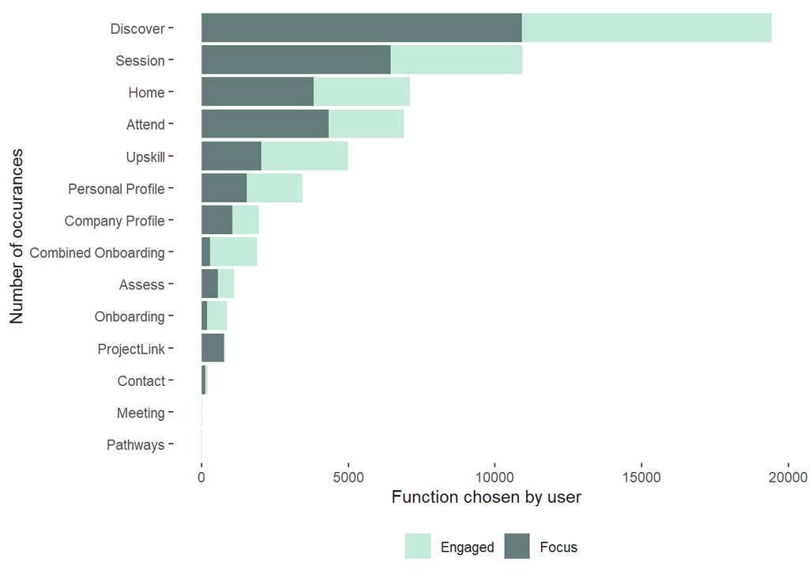

(a) Customers function choice

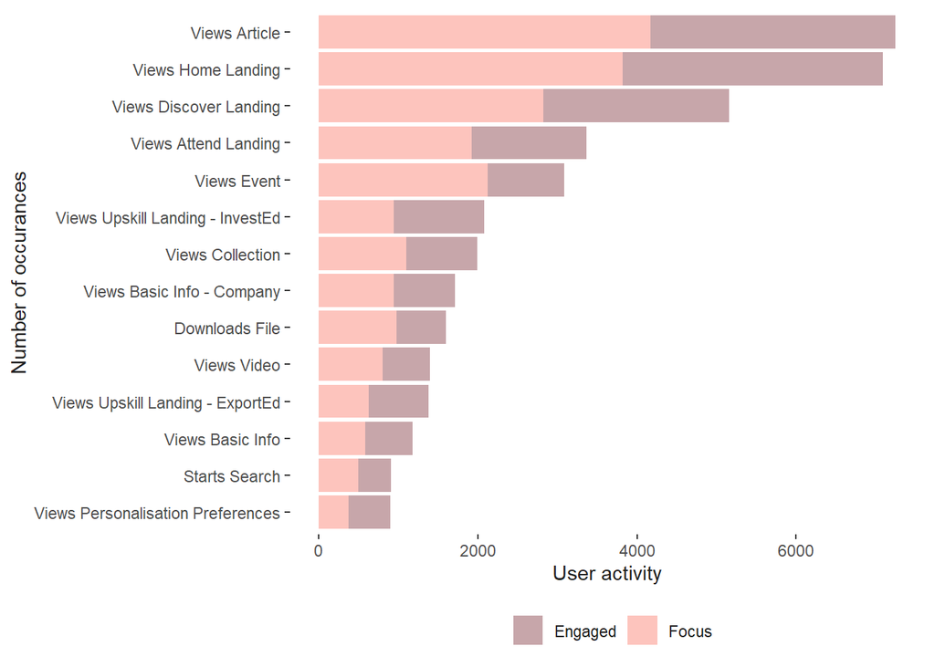

(b) Customer action choice

Figure 5: Where do customers often natigate to

## What are Customers looking for?

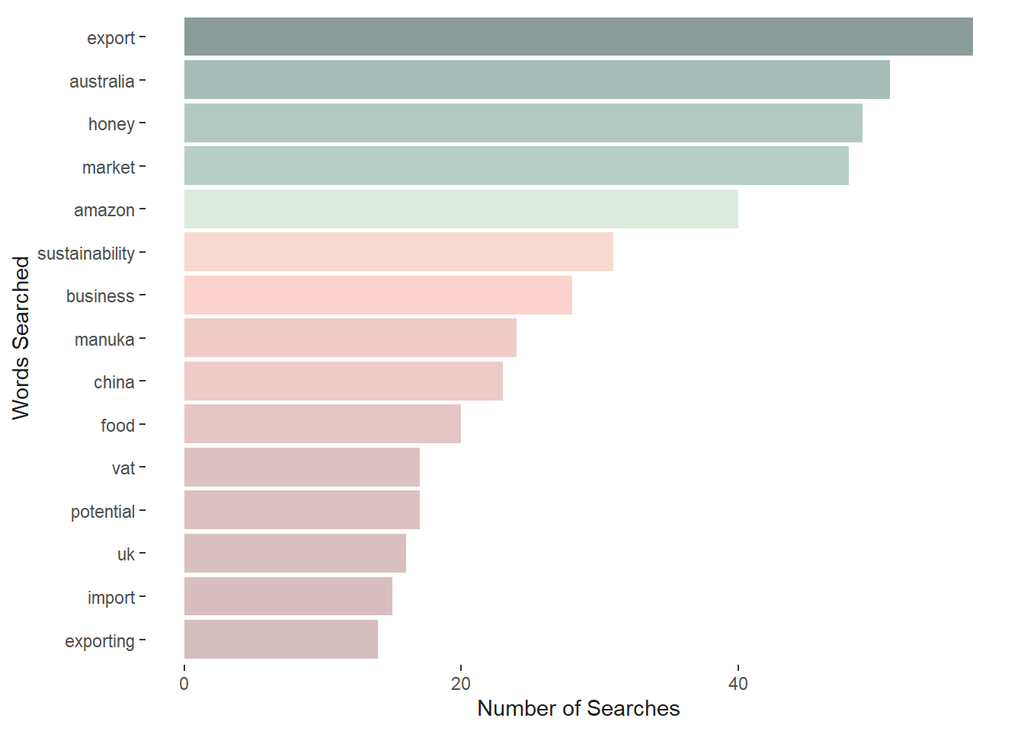

(a) Engaged Customers

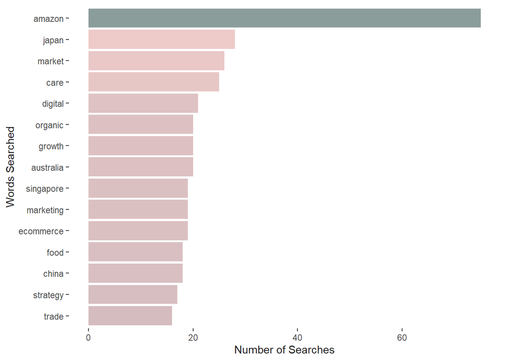

(b) Focus Customers

Figure 6: A frequency word count on search quries

We can also visualise search terms via word clouds, to produce something more evocative. Figure 7 is a combination of word searches across both groups.

[interactive chart not shown]

Figure 7: A wordcloud of search queries

## Customer Target Markets

For organisation where a target market is present ( about 765), the United States (294), Australia (268), China (139), and the United Kingdom (85) are the most targeted markets across those organisations (see Figure 8). Interestingly, despite the limited market access, relative to the other countries, of which New Zealand has trade agreements in place, the United States is still a sought after market for business expansion. The high number of target markets for Australia, may support the narrative that New Zealand businesses looking to export, are said to ‘cut one’s teeth’ on the Australian market first, before expanding further and could represent smaller business who are looking try there hand at exporting. Target market access to China, is likely driven by the food and beverages industries, where price premiums are likely to be the highest.

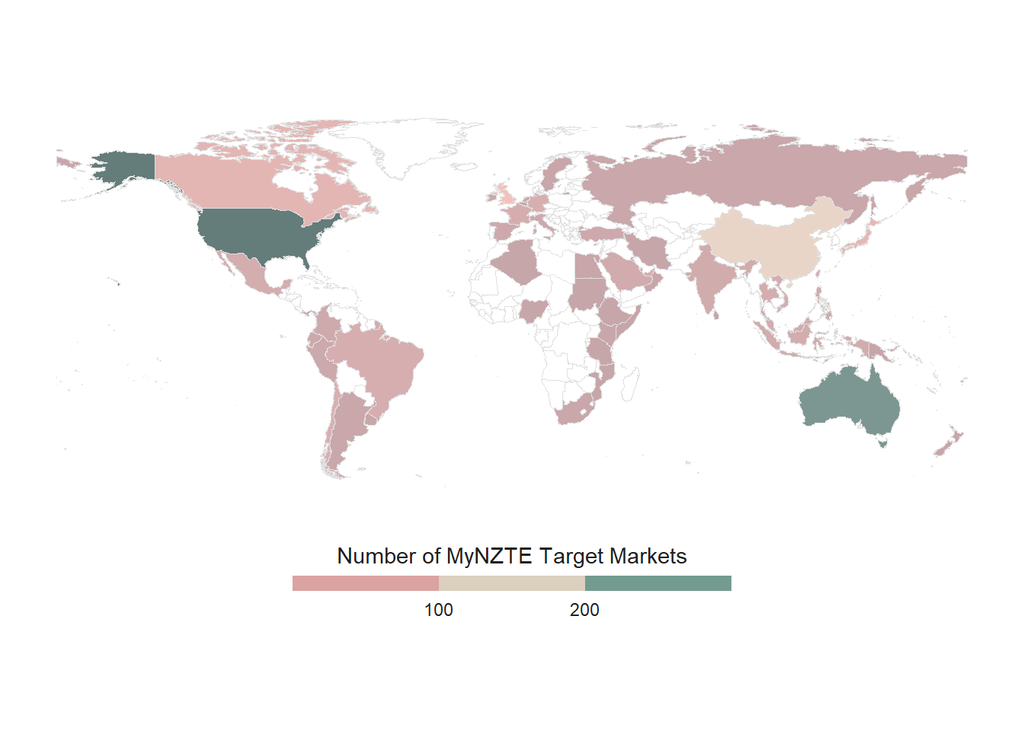

Figure 8: Number of Target Markets by Organisation